# Análisis Univariado y Bivariado

Importamos la data desde el repositorio de Github donde se encuentra nuestra data limpia y mergeada.

```r
library(rio)
link="https://github.com/alessiasibille17/Trabajo_Stad/raw/master/entrega2_final/mergefinal.xlsx"
datamerge=import(link)
```

Antes que nada, y para mayor orden, colocaremos los nombres de los países en row names. Asimismo activamos las librerías que usaremos y eliminaremos la columna con los países

```r
row.names(datamerge)=datamerge$Pais
#Activamos las librerías que usaremos
library(DescTools)
library(psych)
#eliminamos la columna con los países, pues estos ya se encuentran en los row names.
datamerge$Pais= NULL
```

*ANÁLISIS UNIVARIADO* Comenzamos con nuestra variable dependiente: El porcentaje de estudiantes matriculados en educación secundaria a nivel global

```r
#Primero identificamos la variable, vemos la estructura de la data, si nuestra variable se encuentra en numérica, los estadístictos descriptivos a modo de summary.
str(datamerge)
```

```
## 'data.frame':    207 obs. of  9 variables:
##  $ Matricula    : num  50.1 86.6 NA NA 11.3 ...
##  $ PBIPC        : num  552 5224 NA NA 3437 ...
##  $ Pobreza      : num  54.5 14.3 NA NA 36.6 NA 25.7 32 NA NA ...
##  $ URBANO       : num  26 62.1 73.7 NA 66.8 24.4 92.1 63.3 43.7 86.2 ...
##  $ SEXO         : num  48.7 49.1 49.5 NA 50.5 ...
##  $ gastoedu     : num  4.06 2.47 4.34 3.23 3.42 2.52 5.46 2.71 NA 5.27 ...
##  $ profxes      : num  33.5 11.2 NA 8.02 26.77 ...
##  $ totalAC      : num  0.3 37.7 1.5 64.2 33.5 35.3 54.5 16.3 NA 69.3 ...
##  $ rateper1000AP: num  62 15.9 9.7 2.7 163 27.7 54.4 21.2 NA 10.1 ...
```

```r
class(datamerge$Matricula)
```

```
## [1] "numeric"
```

```r
summary(datamerge$Matricula)
```

```
##    Min. 1st Qu.  Median    Mean 3rd Qu.    Max.    NA's
##    5.48   57.52   82.07   72.01   90.89   99.84      44
```

```r
table(datamerge$Matricula)
```

```
##
##  5.48 11.29 12.72 15.69 18.86 19.28 20.07 26.55 27.52 29.85 29.93 30.81 30.98
##     1     1     1     1     1     1     1     1     1     1     1     1     1
##    31  31.5 32.21 32.38 34.24 35.87  37.4 37.67 37.82  40.2 41.01 41.35 41.58
##     1     1     1     1     1     1     1     1     1     1     1     1     1
##  41.7 41.77 43.78 45.99 46.58 47.59 48.42  48.5 48.73 48.94 50.14 50.36 55.85
##     1     1     2     1     1     1     1     1     1     1     1     1     1
## 57.24 57.79 60.01 61.63 61.83 61.87  62.5  62.6 62.74 63.79 64.06 64.49 65.23
##     1     1     1     1     1     1     1     1     1     1     1     1     1
## 65.56 65.88 66.54 66.55 66.73 68.11  70.2 70.43 70.61 71.15 71.81 71.93 72.21
##     1     1     1     1     1     1     1     1     1     1     1     1     1
## 72.77 73.24 73.97 75.92 76.55 76.95 77.27 77.47 77.96 78.73 80.06 81.16 81.31
##     1     1     1     1     1     1     1     1     1     1     1     1     1
## 81.38 81.73 82.07 82.34 82.45 82.65 82.78 82.85 83.22 83.58 84.18 84.31 84.39
##     1     1     1     1     1     1     1     1     1     1     1     1     1
## 84.52 84.67 84.76  85.3 85.33 85.52 85.68 85.94 86.53 86.61    87 87.23 87.73
##     1     1     1     1     1     1     1     1     1     1     1     2     1
## 87.74 88.21 88.53 88.65 88.79 89.06 89.07 89.28 89.31 89.47 90.19 90.52 90.68
##     2     1     1     1     1     1     1     1     1     1     1     1     1
##  90.8 90.86 90.92 91.04 91.27 92.07 92.28 92.39 92.45  92.8 92.96 93.16 93.35
##     1     1     1     1     1     1     1     1     1     1     1     1     1
## 93.63  93.8 93.84 93.89 94.08 94.36 94.66 94.67 94.95 95.34 95.61 95.64 95.69
##     1     1     1     1     1     1     2     1     1     1     1     1     1
## 95.95  96.1 96.19 96.36 96.86 96.88 97.13    98 98.01 98.43 98.64 98.66 99.06
##     1     1     1     1     1     1     1     1     1     1     1     1     1
## 99.78 99.81 99.84
##     1     1     1
```

```r
#Ahora pedimos algunos estadísticos descriptivos en particular. Si bien también los tenemos en summary, pedimos la mediana, la desviación estándar.
median(datamerge$Matricula,na.rm=T)
```

```
## [1] 82.07
```

```r
mean(datamerge$Matricula,na.rm=T)
```

```
## [1] 72.01429
```

```r
Mode(datamerge$Matricula,na.rm=T)
```

```
## [1] 43.78 87.23 87.74 94.66
## attr(,"freq")
## [1] 2
```

```r
sd(datamerge$Matricula,na.rm=T)
```

```
## [1] 23.95137
```

```r
prop.table(table(datamerge$Matricula))*100
```

```
##
##      5.48     11.29     12.72     15.69     18.86     19.28     20.07     26.55
## 0.6134969 0.6134969 0.6134969 0.6134969 0.6134969 0.6134969 0.6134969 0.6134969
##     27.52     29.85     29.93     30.81     30.98        31      31.5     32.21
## 0.6134969 0.6134969 0.6134969 0.6134969 0.6134969 0.6134969 0.6134969 0.6134969
##     32.38     34.24     35.87      37.4     37.67     37.82      40.2     41.01
## 0.6134969 0.6134969 0.6134969 0.6134969 0.6134969 0.6134969 0.6134969 0.6134969
##     41.35     41.58      41.7     41.77     43.78     45.99     46.58     47.59
## 0.6134969 0.6134969 0.6134969 0.6134969 1.2269939 0.6134969 0.6134969 0.6134969
##     48.42      48.5     48.73     48.94     50.14     50.36     55.85     57.24
## 0.6134969 0.6134969 0.6134969 0.6134969 0.6134969 0.6134969 0.6134969 0.6134969
##     57.79     60.01     61.63     61.83     61.87      62.5      62.6     62.74
## 0.6134969 0.6134969 0.6134969 0.6134969 0.6134969 0.6134969 0.6134969 0.6134969
##     63.79     64.06     64.49     65.23     65.56     65.88     66.54     66.55
## 0.6134969 0.6134969 0.6134969 0.6134969 0.6134969 0.6134969 0.6134969 0.6134969
##     66.73     68.11      70.2     70.43     70.61     71.15     71.81     71.93
## 0.6134969 0.6134969 0.6134969 0.6134969 0.6134969 0.6134969 0.6134969 0.6134969
##     72.21     72.77     73.24     73.97     75.92     76.55     76.95     77.27
## 0.6134969 0.6134969 0.6134969 0.6134969 0.6134969 0.6134969 0.6134969 0.6134969
##     77.47     77.96     78.73     80.06     81.16     81.31     81.38     81.73
## 0.6134969 0.6134969 0.6134969 0.6134969 0.6134969 0.6134969 0.6134969 0.6134969
##     82.07     82.34     82.45     82.65     82.78     82.85     83.22     83.58
## 0.6134969 0.6134969 0.6134969 0.6134969 0.6134969 0.6134969 0.6134969 0.6134969
##     84.18     84.31     84.39     84.52     84.67     84.76      85.3     85.33
## 0.6134969 0.6134969 0.6134969 0.6134969 0.6134969 0.6134969 0.6134969 0.6134969
##     85.52     85.68     85.94     86.53     86.61        87     87.23     87.73
## 0.6134969 0.6134969 0.6134969 0.6134969 0.6134969 0.6134969 1.2269939 0.6134969
##     87.74     88.21     88.53     88.65     88.79     89.06     89.07     89.28
## 1.2269939 0.6134969 0.6134969 0.6134969 0.6134969 0.6134969 0.6134969 0.6134969
##     89.31     89.47     90.19     90.52     90.68      90.8     90.86     90.92
## 0.6134969 0.6134969 0.6134969 0.6134969 0.6134969 0.6134969 0.6134969 0.6134969
##     91.04     91.27     92.07     92.28     92.39     92.45      92.8     92.96
## 0.6134969 0.6134969 0.6134969 0.6134969 0.6134969 0.6134969 0.6134969 0.6134969
##     93.16     93.35     93.63      93.8     93.84     93.89     94.08     94.36
## 0.6134969 0.6134969 0.6134969 0.6134969 0.6134969 0.6134969 0.6134969 0.6134969
##     94.66     94.67     94.95     95.34     95.61     95.64     95.69     95.95
## 1.2269939 0.6134969 0.6134969 0.6134969 0.6134969 0.6134969 0.6134969 0.6134969
##      96.1     96.19     96.36     96.86     96.88     97.13        98     98.01
## 0.6134969 0.6134969 0.6134969 0.6134969 0.6134969 0.6134969 0.6134969 0.6134969
##     98.43     98.64     98.66     99.06     99.78     99.81     99.84
## 0.6134969 0.6134969 0.6134969 0.6134969 0.6134969 0.6134969 0.6134969
```

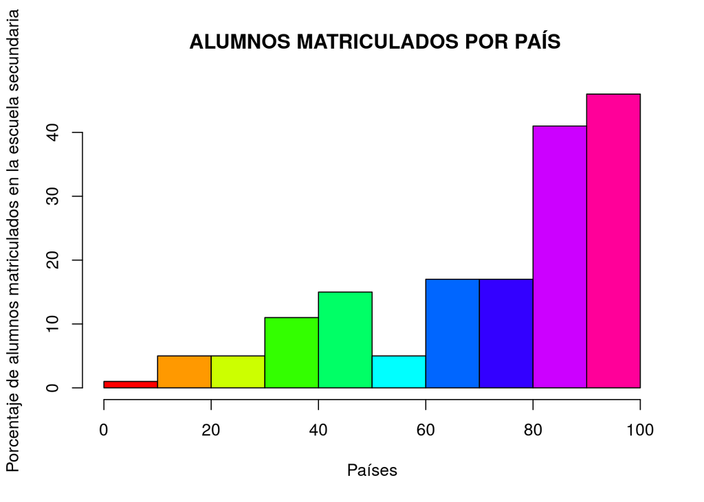

```r
#Ahora, procedemos a realizar nuestro primer gráfico: Histograma de la variable
graficomatricula <- (datamerge$Matricula)
hist(graficomatricula, col= rainbow(10),
     xlab="Países",
     ylab="Porcentaje de alumnos matriculados en la escuela secundaria",
     main=" ALUMNOS MATRICULADOS POR PAÍS")
```

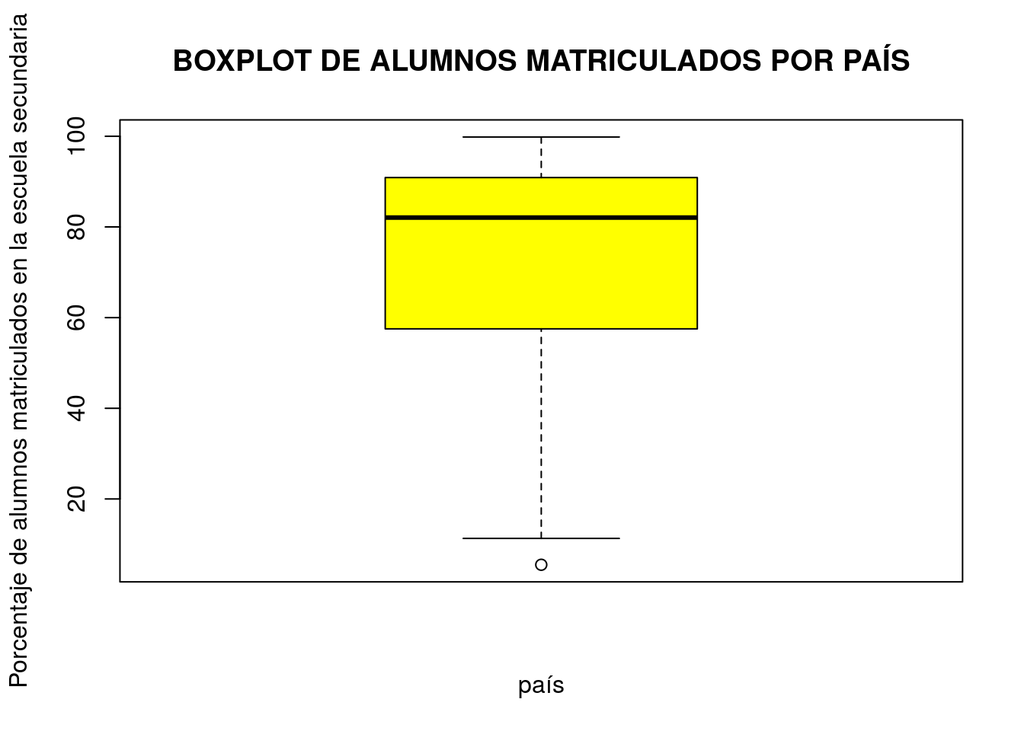

```r
#Haremos nuestro segundo gráfico: Boxplot de la variable. Esto nos servirá para ver cómo se distribuyen los casos.
boxplot(datamerge$Matricula, main="BOXPLOT DE ALUMNOS MATRICULADOS POR PAÍS", col="Yellow",
        xlab="país", ylab="Porcentaje de alumnos matriculados en la escuela secundaria")
```

```r
#Retomando el tema de los estadísticos, podemos visualizarlos de una manera más clara haciendo uso del comando table1.
library(table1)
table1::label(datamerge$Matricula) <- "Porcentaje de alumnos matriculados en el nivel secundario"
table1(~Matricula, data = datamerge)
```

|  | Overall (N=207) |
| --- | --- |
| Porcentaje de alumnos matriculados en el nivel secundario |  |
| Mean (SD) | 72.0 (24.0) |
| Median [Min, Max] | 82.1 [5.48, 99.8] |
| Missing | 44 (21.3%) |

```r
table1
```

```
## function (x, ...)
## {
##     UseMethod("table1")
## }
## <bytecode: 0xb5a9df8>
## <environment: namespace:table1>
```

Análisis univariado de variables independientes: 1. Variable PBI per cápita por país (nominal)

```r
##Primero identificamos la variable, vemos la estructura de la data, si nuestra variable se encuentra en numérica, los estadístictos descriptivos a modo de summary.
str(datamerge)
```

```
## 'data.frame':    207 obs. of  9 variables:
##  $ Matricula    : num  50.1 86.6 NA NA 11.3 ...
##   ..- attr(*, "label")= chr "Porcentaje de alumnos matriculados en el nivel secundario"
##  $ PBIPC        : num  552 5224 NA NA 3437 ...
##  $ Pobreza      : num  54.5 14.3 NA NA 36.6 NA 25.7 32 NA NA ...
##  $ URBANO       : num  26 62.1 73.7 NA 66.8 24.4 92.1 63.3 43.7 86.2 ...
##  $ SEXO         : num  48.7 49.1 49.5 NA 50.5 ...
##  $ gastoedu     : num  4.06 2.47 4.34 3.23 3.42 2.52 5.46 2.71 NA 5.27 ...
##  $ profxes      : num  33.5 11.2 NA 8.02 26.77 ...
##  $ totalAC      : num  0.3 37.7 1.5 64.2 33.5 35.3 54.5 16.3 NA 69.3 ...
##  $ rateper1000AP: num  62 15.9 9.7 2.7 163 27.7 54.4 21.2 NA 10.1 ...
```

```r
class(datamerge$PBIPC)
```

```
## [1] "numeric"
```

```r
summary(datamerge$PBIPC)
```

```
##    Min. 1st Qu.  Median    Mean 3rd Qu.    Max.    NA's
##     294    2040    6798   18564   23419  179258      65
```

```r
table(datamerge$PBIPC)
```

```
##
##    293.96    396.63    440.25    480.71    498.94     527.4    536.11    551.87
##         1         1         1         1         1         1         1         1
##    571.27    654.76    735.11    735.73    747.72    773.05    820.17    826.62
##         1         1         1         1         1         1         1         1
##     900.1    906.54     937.6     981.3    990.56   1208.44   1248.02   1330.39
##         1         1         1         1         1         1         1         1
##   1354.45   1400.53   1501.72   1534.49   1554.98    1670.8   1683.77   1730.44
##         1         1         1         1         1         1         1         1
##   1948.11   1985.43    2028.9   2035.53   2054.76   2201.58   2500.11   2681.43
##         1         1         1         1         1         1         1         1
##   2956.92   3037.22   3048.59   3102.73   3272.95    3437.3    3523.8   3635.41
##         1         1         1         1         1         1         1         1
##    3666.9   3893.49   4000.62   4058.24   4189.69   4212.13    4237.8   4249.57
##         1         1         1         1         1         1         1         1
##   4396.67   4549.02   4717.72   4884.74   4885.81   4900.76   5223.81   5354.25
##         1         1         1         1         1         1         1         1
##   5794.58   6003.72   6267.03   6311.72   6344.87   6369.23   6649.64   6947.25
##         1         1         1         1         1         1         1         1
##   7208.78   7273.56   7650.09   7691.35   8771.69   8821.82    8920.7   9367.92
##         1         1         1         1         1         1         1         1
##   9387.81   9694.85    9789.5  10485.91  11221.98  11373.35  11394.14   11687.6
##         1         1         1         1         1         1         1         1
##  11875.86  12026.55  12280.84  14674.02     15444  15575.08  15923.36  16264.02
##         1         1         1         1         1         1         1         1
##  16377.86  16726.98  17278.06  17745.87  17851.58  19072.78  19082.52   20731.2
##         1         1         1         1         1         1         1         1
##   23217.2  23241.89  23477.73  24133.55   26005.1  28967.58  30262.49  30405.83
##         1         1         1         1         1         1         1         1
##  31627.23   33122.8  33271.16  34248.84  34388.51  41358.09  43004.95  43836.15
##         1         1         1         1         1         1         1         1
##  44214.91  46192.38  47292.97   47513.7  48472.71  48511.26  50135.72  51230.28
##         1         1         1         1         1         1         1         1
##  53583.14  55766.81  58392.71  61833.71  62720.88  62917.94  68793.66   76867.3
##         1         1         1         1         1         1         1         1
##   79414.6  81335.65  82708.51 101207.85 117369.54 179258.25
##         1         1         1         1         1         1
```

```r
#Ahora pedimos algunos estadísticos descriptivos en particular. Si bien también los tenemos en summary, pedimos la mediana, la desviación estándar.
median(datamerge$PBIPC,na.rm=T)
```

```
## [1] 6798.445
```

```r
mean(datamerge$PBIPC,na.rm=T)
```

```
## [1] 18563.8
```

```r
Mode(datamerge$PBIPC,na.rm=T)
```

```
## [1] NA
## attr(,"freq")
## [1] 1
```

```r
sd(datamerge$PBIPC,na.rm=T)
```

```
## [1] 26672.1
```

```r
prop.table(table(datamerge$PBIPC))*100
```

```
##
##    293.96    396.63    440.25    480.71    498.94     527.4    536.11    551.87
## 0.7042254 0.7042254 0.7042254 0.7042254 0.7042254 0.7042254 0.7042254 0.7042254
##    571.27    654.76    735.11    735.73    747.72    773.05    820.17    826.62
## 0.7042254 0.7042254 0.7042254 0.7042254 0.7042254 0.7042254 0.7042254 0.7042254
##     900.1    906.54     937.6     981.3    990.56   1208.44   1248.02   1330.39
## 0.7042254 0.7042254 0.7042254 0.7042254 0.7042254 0.7042254 0.7042254 0.7042254
##   1354.45   1400.53   1501.72   1534.49   1554.98    1670.8   1683.77   1730.44
## 0.7042254 0.7042254 0.7042254 0.7042254 0.7042254 0.7042254 0.7042254 0.7042254
##   1948.11   1985.43    2028.9   2035.53   2054.76   2201.58   2500.11   2681.43
## 0.7042254 0.7042254 0.7042254 0.7042254 0.7042254 0.7042254 0.7042254 0.7042254
##   2956.92   3037.22   3048.59   3102.73   3272.95    3437.3    3523.8   3635.41
## 0.7042254 0.7042254 0.7042254 0.7042254 0.7042254 0.7042254 0.7042254 0.7042254
##    3666.9   3893.49   4000.62   4058.24   4189.69   4212.13    4237.8   4249.57
## 0.7042254 0.7042254 0.7042254 0.7042254 0.7042254 0.7042254 0.7042254 0.7042254
##   4396.67   4549.02   4717.72   4884.74   4885.81   4900.76   5223.81   5354.25
## 0.7042254 0.7042254 0.7042254 0.7042254 0.7042254 0.7042254 0.7042254 0.7042254
##   5794.58   6003.72   6267.03   6311.72   6344.87   6369.23   6649.64   6947.25
## 0.7042254 0.7042254 0.7042254 0.7042254 0.7042254 0.7042254 0.7042254 0.7042254
##   7208.78   7273.56   7650.09   7691.35   8771.69   8821.82    8920.7   9367.92
## 0.7042254 0.7042254 0.7042254 0.7042254 0.7042254 0.7042254 0.7042254 0.7042254
##   9387.81   9694.85    9789.5  10485.91  11221.98  11373.35  11394.14   11687.6
## 0.7042254 0.7042254 0.7042254 0.7042254 0.7042254 0.7042254 0.7042254 0.7042254
##  11875.86  12026.55  12280.84  14674.02     15444  15575.08  15923.36  16264.02
## 0.7042254 0.7042254 0.7042254 0.7042254 0.7042254 0.7042254 0.7042254 0.7042254
##  16377.86  16726.98  17278.06  17745.87  17851.58  19072.78  19082.52   20731.2
## 0.7042254 0.7042254 0.7042254 0.7042254 0.7042254 0.7042254 0.7042254 0.7042254
##   23217.2  23241.89  23477.73  24133.55   26005.1  28967.58  30262.49  30405.83
## 0.7042254 0.7042254 0.7042254 0.7042254 0.7042254 0.7042254 0.7042254 0.7042254
##  31627.23   33122.8  33271.16  34248.84  34388.51  41358.09  43004.95  43836.15
## 0.7042254 0.7042254 0.7042254 0.7042254 0.7042254 0.7042254 0.7042254 0.7042254
##  44214.91  46192.38  47292.97   47513.7  48472.71  48511.26  50135.72  51230.28
## 0.7042254 0.7042254 0.7042254 0.7042254 0.7042254 0.7042254 0.7042254 0.7042254
##  53583.14  55766.81  58392.71  61833.71  62720.88  62917.94  68793.66   76867.3
## 0.7042254 0.7042254 0.7042254 0.7042254 0.7042254 0.7042254 0.7042254 0.7042254
##   79414.6  81335.65  82708.51 101207.85 117369.54 179258.25
## 0.7042254 0.7042254 0.7042254 0.7042254 0.7042254 0.7042254
```

```r
#Para visualizar los descriptivos de manera más clara
table1::label(datamerge$PBIPC) <- "PBI per cápita (nominal) por país"
table1(~PBIPC, data = datamerge, )
```

|  | Overall (N=207) |
| --- | --- |
| PBI per cápita (nominal) por país |  |
| Mean (SD) | 18600 (26700) |
| Median [Min, Max] | 6800 [294, 179000] |
| Missing | 65 (31.4%) |

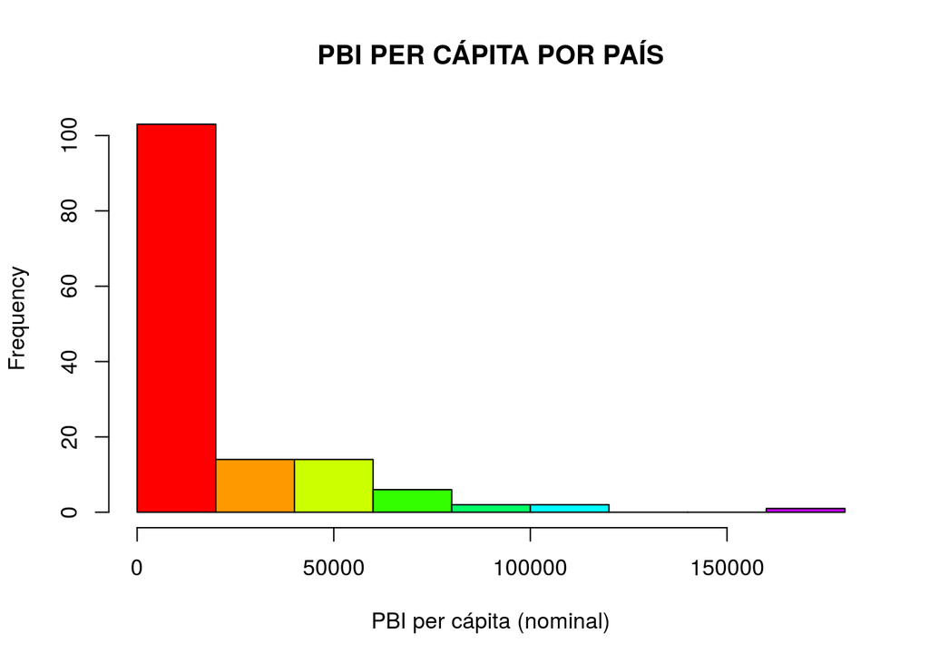

```r
#Ahora, procedemos a realizar nuestro primer gráfico: Histograma de la variable
graficoPBIPC <- (datamerge$PBIPC)
hist(graficoPBIPC, col= rainbow(10),
     xlab="PBI per cápita (nominal)",
     main="PBI PER CÁPITA POR PAÍS")
```

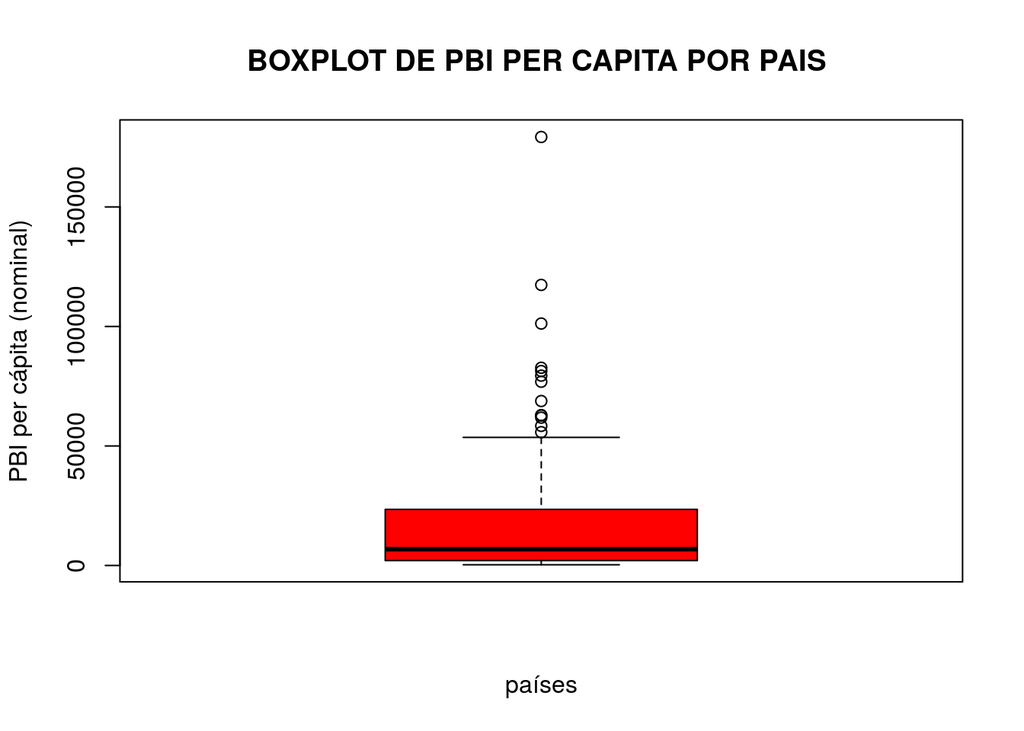

```r
#Haremos nuestro segundo gráfico: Boxplot de la variable. Esto nos servirá para ver cómo se distribuyen los casos.
boxplot(datamerge$PBIPC, main="BOXPLOT DE PBI PER CAPITA POR PAIS ", col="Red",xlab="países",ylab="PBI per cápita (nominal)")
```

2.Variable Porcentaje de la población bajo la línea nacional de pobreza

```r
##Primero identificamos la variable,si nuestra variable se encuentra en numérica, los estadístictos descriptivos a modo de summary.
class(datamerge$Pobreza)
```

```
## [1] "numeric"
```

```r
summary(datamerge$Pobreza)
```

```
##    Min. 1st Qu.  Median    Mean 3rd Qu.    Max.    NA's
##    2.60   14.40   23.00   28.02   38.60   72.30      86
```

```r
table(datamerge$Pobreza)
```

```
##
##  2.6    3  3.8  4.2  4.9  5.7  6.6  6.7  7.2    8  8.2  8.6  8.8  8.9    9  9.2
##    1    1    2    1    1    1    1    1    1    1    1    1    1    1    1    1
##  9.3  9.4  9.6  9.7 10.9   11   12 13.4 13.9   14 14.2 14.3 14.4 14.9   15 15.1
##    1    1    1    1    1    1    1    1    1    1    2    1    1    1    3    2
## 16.3 16.6 16.7 17.1 17.6   19 19.5 21.1 21.5 21.6 21.7 21.9   22 22.2 22.4 22.5
##    1    1    1    1    1    1    2    2    1    1    1    2    1    2    1    1
## 22.7 22.8   23 23.4 24.2 24.3 25.2 25.5 25.7 26.3   28   29 29.5 29.6 29.9   30
##    1    1    2    1    1    1    1    1    1    1    1    1    1    3    1    2
## 30.5   31 31.5   32 32.7   35   36 36.1 36.2 36.6   37   38 38.6 39.1 39.3 40.1
##    1    2    1    1    1    1    1    1    1    1    1    1    1    1    1    1
##   41 41.8 44.8 45.4 46.1 46.2 46.3 46.5 46.7   47   50 50.7 54.1 54.5 55.1   57
##    1    1    1    1    1    1    1    1    2    1    1    1    1    1    1    1
## 59.3   62   63 64.6   66 66.2   70 70.2 70.7 72.3
##    1    1    1    1    1    1    1    1    1    1
```

```r
#Ahora pedimos algunos estadísticos descriptivos en particular. Si bien también los tenemos en summary, pedimos la mediana, la desviación estándar.
median(datamerge$Pobreza,na.rm=T)
```

```
## [1] 23
```

```r
mean(datamerge$Pobreza,na.rm=T)
```

```
## [1] 28.01818
```

```r
Mode(datamerge$Pobreza,na.rm=T)
```

```
## [1] 15.0 29.6
## attr(,"freq")
## [1] 3
```

```r
sd(datamerge$Pobreza,na.rm=T)
```

```
## [1] 17.65422
```

```r
#Para visualizar los descriptivos de manera más clara
table1::label(datamerge$Pobreza) <- "Porcentaje de la población bajo la línea nacional de pobreza"
table1::table1(~Pobreza, data = datamerge, )
```

|  | Overall (N=207) |
| --- | --- |
| Porcentaje de la población bajo la línea nacional de pobreza |  |
| Mean (SD) | 28.0 (17.7) |
| Median [Min, Max] | 23.0 [2.60, 72.3] |
| Missing | 86 (41.5%) |

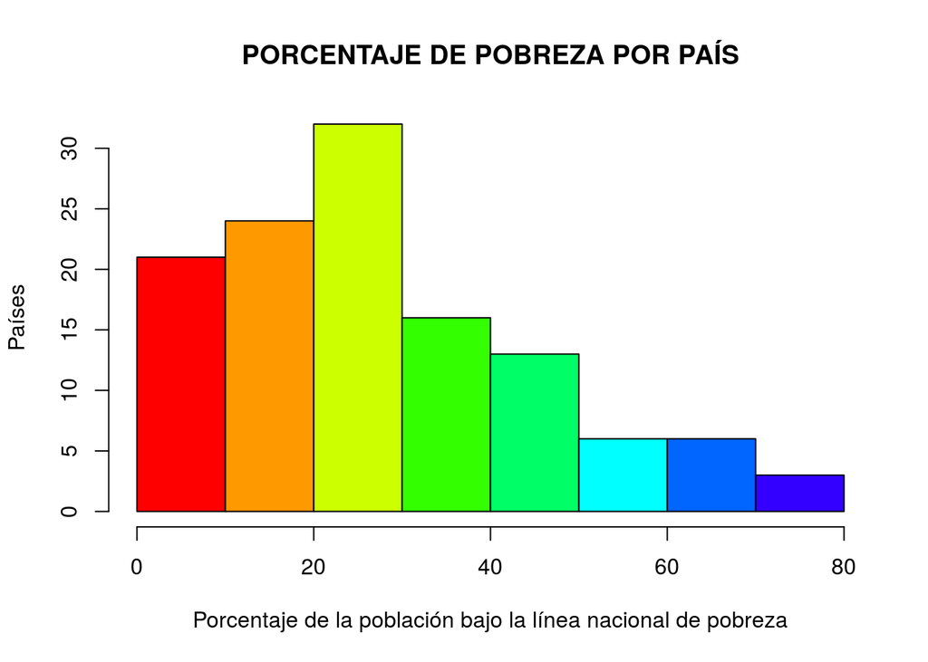

```r
#Ahora, procedemos a realizar nuestro primer gráfico: Histograma de la variable
graficopobreza <- (datamerge$Pobreza)
hist(graficopobreza, col= rainbow(10),
     main="PORCENTAJE DE POBREZA POR PAÍS",
     xlab="Porcentaje de la población bajo la línea nacional de pobreza",ylab="Países")
```

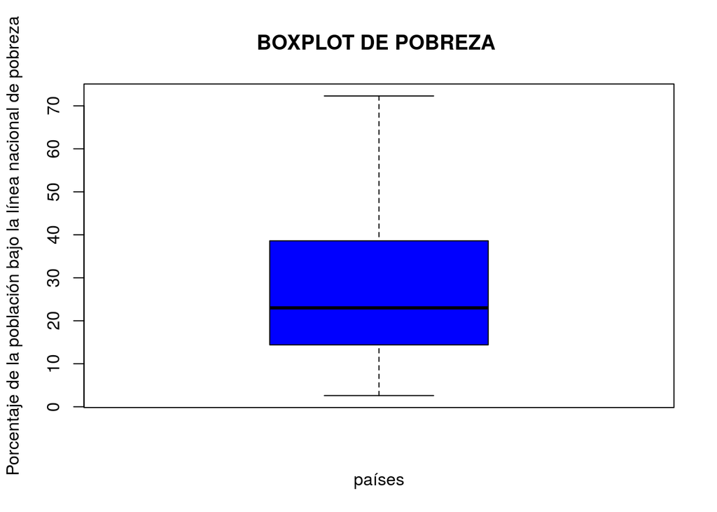

```r
#Haremos nuestro segundo gráfico: Boxplot de la variable. Esto nos servirá para ver cómo se distribuyen los casos.
boxplot(datamerge$Pobreza, main="BOXPLOT DE POBREZA ", col="Blue",
        xlab="países", ylab="Porcentaje de la población bajo la línea nacional de pobreza")
```

3. Variable Porcentaje de población urbana por país.

```r
##Primero identificamos la variable, si nuestra variable se encuentra en numérica, los estadístictos descriptivos a modo de summary.
class(datamerge$URBANO)
```

```
## [1] "numeric"
```

```r
summary(datamerge$URBANO)
```

```
##    Min. 1st Qu.  Median    Mean 3rd Qu.    Max.    NA's
##   13.30   42.55   59.50   59.79   79.60  100.00      44
```

```r
table(datamerge$URBANO)
```

```
##
## 13.3 13.7 16.6 17.4 18.7 20.2 20.6 21.7 23.1 23.5 24.2 24.4 24.7   25 25.5   26
##    1    1    1    2    1    1    1    1    1    1    2    1    1    1    1    1
## 26.8 27.5   28   29 29.4 30.6 31.1 31.2 32.2 34.9 35.2 35.3 36.5 37.1 37.2 37.3
##    1    1    1    1    1    1    1    1    1    1    1    1    1    1    1    1
## 38.2 38.5 40.7 40.8 41.3 42.2 42.3 42.8 42.9 43.7 43.9 44.2 44.6   46 46.1 47.4
##    1    1    1    1    1    1    1    2    1    1    1    1    1    1    1    1
## 48.1 48.4   49 50.4 51.4 51.8   52 52.1 52.5 53.2 55.1 55.3 55.6 56.3 56.4 56.6
##    1    1    1    1    1    1    2    1    1    1    1    1    1    1    3    1
## 57.1 57.2 57.3 57.5 57.6 57.7 58.4 58.5 58.7   59 59.5   60 61.4   62 62.1 62.2
##    1    1    1    1    2    1    1    1    1    1    1    1    1    1    1    1
## 63.3 63.5 63.7 64.2 66.1 66.3 66.8 67.4 67.5   68 68.3 68.4 68.7 69.2 69.6 70.1
##    1    1    1    1    1    1    2    1    1    1    1    1    1    1    2    1
## 70.9   71 71.9 73.1 73.4 73.7 73.9 74.1 75.7 76.1 77.2 77.5 78.1 78.3 79.5 79.7
##    2    1    1    1    1    1    1    1    1    1    2    1    1    1    1    1
## 80.7 80.8   81 81.4 81.6 82.5 82.7   83 83.9 84.3 85.5 86.2 86.3 86.7   87 87.1
##    2    2    1    1    1    1    1    1    1    1    1    1    1    1    1    1
## 87.7   88 88.1 88.9 89.1 89.5 90.1 91.4 91.5 91.8 92.1 92.2 92.6 93.6 93.9 94.7
##    1    1    1    1    1    1    1    1    1    1    1    1    1    1    1    1
## 94.9 95.5 98.1 99.2  100
##    1    1    1    1    2
```

```r
#Ahora pedimos algunos estadísticos descriptivos en particular. Si bien también los tenemos en summary, pedimos la mediana, la desviación estándar.
median(datamerge$URBANO,na.rm=T)
```

```
## [1] 59.5
```

```r
mean(datamerge$URBANO,na.rm=T)
```

```
## [1] 59.78834
```

```r
Mode(datamerge$URBANO,na.rm=T)
```

```
## [1] 56.4
## attr(,"freq")
## [1] 3
```

```r
sd(datamerge$URBANO,na.rm=T)
```

```
## [1] 22.95692
```

```r
#Para visualizar los descriptivos de manera más clara
table1::label(datamerge$URBANO) <- "Porcentaje de población urbana por país"
table1::table1(~URBANO, data = datamerge, )
```

|  | Overall (N=207) |
| --- | --- |
| Porcentaje de población urbana por país |  |
| Mean (SD) | 59.8 (23.0) |
| Median [Min, Max] | 59.5 [13.3, 100] |
| Missing | 44 (21.3%) |

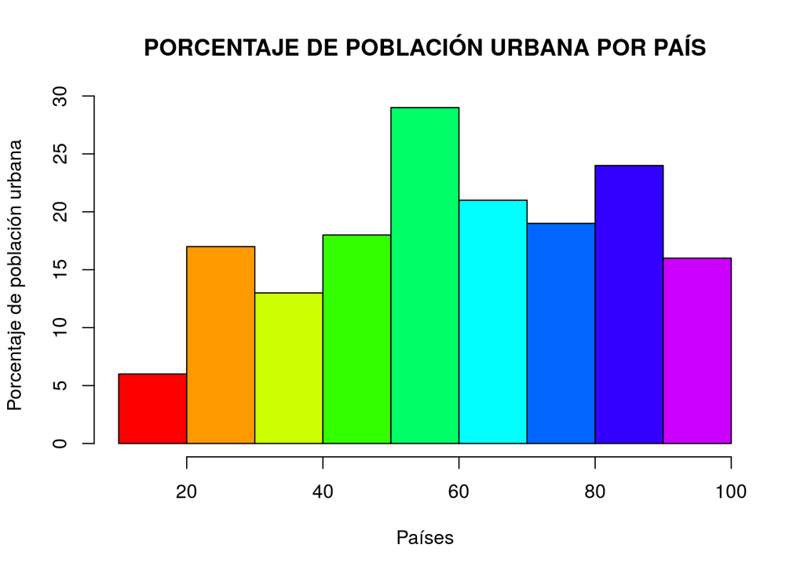

```r
#Ahora, procedemos a realizar nuestro primer gráfico: Histograma de la variable
graficourbano <- (datamerge$URBANO)
hist(graficourbano, col= rainbow(10),
     xlab="Países",
     ylab="Porcentaje de población urbana",
     main="PORCENTAJE DE POBLACIÓN URBANA POR PAÍS")
```

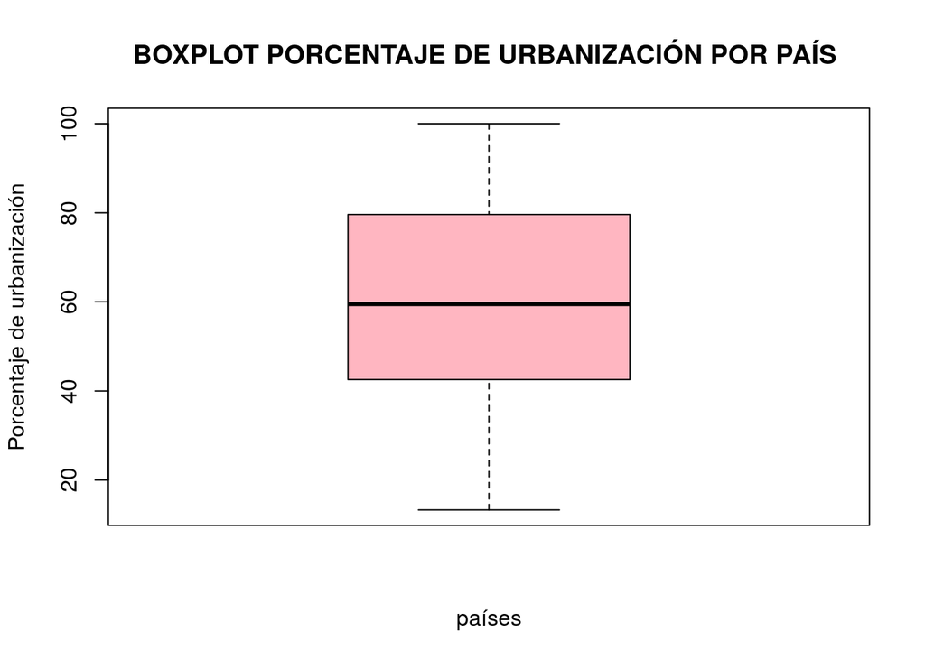

```r
#Haremos nuestro segundo gráfico: Boxplot de la variable. Esto nos servirá para ver cómo se distribuyen los casos.
boxplot(datamerge$URBANO, main="BOXPLOT PORCENTAJE DE URBANIZACIÓN POR PAÍS ", col="light pink",
        xlab="países", ylab="Porcentaje de urbanización")
```

4.Variable: Porcentaje de población femenina por país

```r
##Primero identificamos la variable, si nuestra variable se encuentra en numérica, los estadístictos descriptivos a modo de summary.
class(datamerge$SEXO)
```

```
## [1] "numeric"
```

```r
summary(datamerge$SEXO)
```

```
##    Min. 1st Qu.  Median    Mean 3rd Qu.    Max.    NA's
##   24.67   49.75   50.33   49.81   50.99   54.40      44
```

```r
table(datamerge$SEXO)
```

```
##
## 24.67 30.74 33.98 35.73  36.7 39.08 42.27 44.41 46.92 47.41 47.66 48.03 48.54
##     1     1     1     1     1     1     1     1     1     1     1     1     1
##  48.6 48.66 48.67 48.69 48.95 49.08 49.09 49.15 49.17  49.3 49.32 49.33 49.34
##     1     1     1     1     1     1     1     1     1     1     1     2     1
## 49.38  49.4 49.42 49.47 49.48 49.49  49.5 49.53 49.56  49.6 49.65 49.69 49.73
##     1     1     1     1     1     1     1     1     1     1     1     1     1
## 49.75 49.76 49.79  49.8 49.87 49.88 49.92 49.93 49.95 49.96 49.97 49.98 49.99
##     2     2     1     2     1     1     2     1     1     1     2     1     1
##    50 50.02 50.03 50.04 50.06 50.08 50.11 50.12 50.14  50.2 50.22 50.23 50.25
##     1     1     1     3     1     4     1     2     1     2     1     1     1
## 50.26 50.28 50.31 50.33 50.34 50.35 50.38 50.39  50.4 50.41 50.42 50.43 50.49
##     1     1     1     1     1     1     1     2     1     1     1     1     1
##  50.5 50.52 50.53 50.56 50.61 50.62 50.65 50.66 50.69  50.7 50.71 50.72 50.74
##     1     1     1     1     3     1     1     1     2     2     2     1     2
## 50.76 50.79 50.83 50.84 50.85 50.87 50.91 50.92 50.98 51.01 51.02 51.09 51.12
##     2     1     1     1     2     1     1     1     1     1     1     1     1
## 51.17 51.19 51.23 51.24  51.3 51.34 51.36 51.43 51.44 51.49 51.54  51.6 51.64
##     1     1     1     1     1     1     1     1     1     1     2     1     2
##  51.7 51.72 51.76 51.81 51.82 52.01 52.07 52.32 52.42 52.55  52.7 52.73 52.96
##     1     1     1     1     1     1     1     2     1     2     1     1     1
## 53.15 53.45 53.68 53.74 53.96 54.06  54.4
##     1     1     1     1     1     1     1
```

```r
#Ahora pedimos algunos estadísticos descriptivos en particular. Si bien también los tenemos en summary, pedimos la mediana, la desviación estándar.
median(datamerge$SEXO,na.rm=T)
```

```
## [1] 50.33
```

```r
mean(datamerge$SEXO,na.rm=T)
```

```
## [1] 49.80791
```

```r
Mode(datamerge$SEXO,na.rm=T)
```

```
## [1] 50.08
## attr(,"freq")
## [1] 4
```

```r
sd(datamerge$SEXO,na.rm=T)
```

```
## [1] 3.625772
```

```r
#Para visualizar los descriptivos de manera más clara
table1::label(datamerge$SEXO) <- "Porcentaje de población femenina"
table1::table1(~SEXO, data = datamerge, )
```

|  | Overall (N=207) |
| --- | --- |
| Porcentaje de población femenina |  |
| Mean (SD) | 49.8 (3.63) |
| Median [Min, Max] | 50.3 [24.7, 54.4] |
| Missing | 44 (21.3%) |

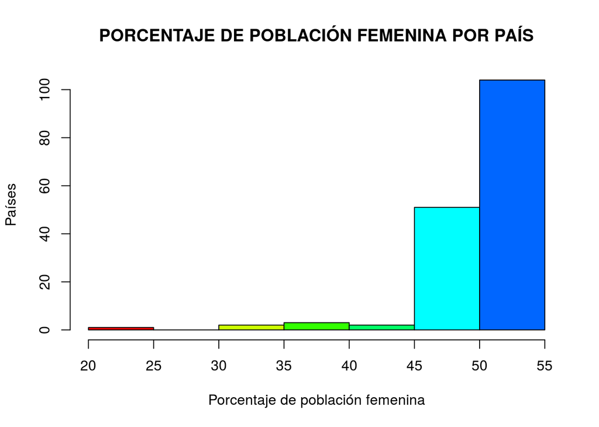

```r
#Ahora, procedemos a realizar nuestro primer gráfico: Histograma de la variable
graficosexo <- (datamerge$SEXO)
hist(graficosexo, col= rainbow(10),
     xlab="Porcentaje de población femenina",
     ylab="Países",
     main="PORCENTAJE DE POBLACIÓN FEMENINA POR PAÍS")
```

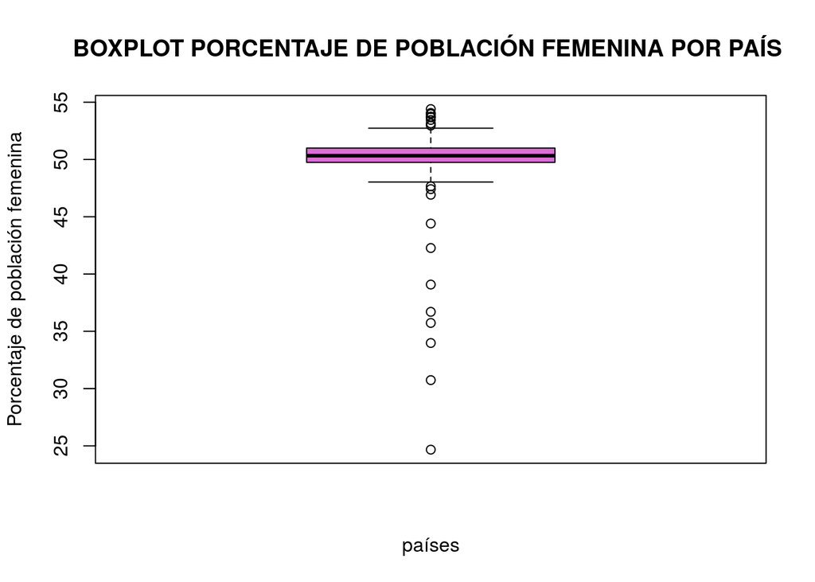

```r
#Haremos nuestro segundo gráfico: Boxplot de la variable. Esto nos servirá para ver cómo se distribuyen los casos.
boxplot(datamerge$SEXO, main="BOXPLOT PORCENTAJE DE POBLACIÓN FEMENINA POR PAÍS ", col="orchid",
        xlab="países", ylab="Porcentaje de población femenina")
```

5.Variable Porcentaje del PBI invertido en educación por parte del Estado

```r
##Primero identificamos la variable, si nuestra variable se encuentra en numérica, los estadístictos descriptivos a modo de summary.
class(datamerge$gastoedu)
```

```
## [1] "numeric"
```

```r
summary(datamerge$gastoedu)
```

```
##    Min. 1st Qu.  Median    Mean 3rd Qu.    Max.    NA's
##   0.720   3.145   4.170   4.455   5.300  12.840      16
```

```r
table(datamerge$gastoedu)
```

```
##
##  0.72  0.98  1.11  1.28  1.45  1.46  1.89  1.93  1.97  1.99  2.11  2.13  2.16
##     1     1     2     1     1     1     1     1     1     1     1     2     1
##  2.22  2.23  2.24  2.26  2.33  2.43  2.47  2.49  2.52  2.56  2.57  2.58  2.61
##     1     1     1     1     1     2     2     1     2     1     1     1     1
##  2.63  2.65  2.67  2.71  2.75  2.78  2.85  2.86   2.9  2.93  2.94  2.97  3.05
##     1     1     1     1     1     1     1     1     1     1     1     1     1
##  3.06   3.1  3.11  3.14  3.15  3.16  3.17  3.19  3.23   3.3  3.32  3.39  3.42
##     1     1     1     1     2     1     1     1     2     1     1     1     1
##  3.44  3.55  3.58  3.59   3.6  3.64  3.68   3.7  3.72  3.73  3.74  3.76  3.79
##     1     1     1     1     1     1     1     1     3     1     2     2     1
##  3.83  3.84  3.85  3.88   3.9  3.91  3.96  3.99  4.01  4.04  4.06  4.07  4.08
##     1     1     1     1     1     1     3     1     1     1     1     1     2
##  4.09  4.12  4.13  4.17  4.21  4.29  4.34  4.37  4.42  4.43   4.5  4.53  4.56
##     1     1     1     1     1     1     2     1     1     1     1     1     1
##  4.59   4.6  4.64  4.65  4.66  4.67   4.7  4.71  4.72  4.74  4.79   4.8  4.83
##     1     1     1     1     1     1     1     2     1     1     1     2     1
##  4.84  4.88  4.91  4.92  4.96     5  5.01  5.11  5.13  5.14  5.15  5.16  5.17
##     1     1     2     1     1     1     1     1     1     1     2     1     2
##   5.2  5.23  5.25  5.27  5.28  5.32   5.4  5.41  5.43  5.46  5.48  5.49   5.5
##     1     1     1     2     1     1     1     2     1     2     1     1     1
##  5.51  5.56  5.59   5.6  5.68  5.85  5.89  6.03  6.04  6.08  6.16  6.24  6.25
##     1     1     1     1     1     1     1     1     1     1     1     1     1
##  6.29  6.44  6.51  6.55   6.6  6.64  6.67  6.87   6.9  7.03  7.13  7.14  7.29
##     1     1     1     1     1     1     1     1     1     1     1     1     1
##  7.38  7.46  7.58  7.63  7.67  7.98  9.63  9.86 11.99 12.24 12.46 12.84
##     1     1     1     1     1     1     1     1     1     1     1     1
```

```r
#Ahora pedimos algunos estadísticos descriptivos en particular. Si bien también los tenemos en summary, pedimos la mediana, la desviación estándar.
median(datamerge$gastoedu,na.rm=T)
```

```
## [1] 4.17
```

```r
mean(datamerge$gastoedu,na.rm=T)
```

```
## [1] 4.454869
```

```r
Mode(datamerge$gastoedu,na.rm=T)
```

```
## [1] 3.72 3.96
## attr(,"freq")
## [1] 3
```

```r
sd(datamerge$gastoedu,na.rm=T)
```

```
## [1] 1.985327
```

```r
#Para visualizar los descriptivos de manera más clara
table1::label(datamerge$gastoedu) <- "Porcentaje del PBI invertido en educación por parte del Estado"
table1::table1(~PBIPC, data = datamerge, )
```

|  | Overall (N=207) |
| --- | --- |
| PBI per cápita (nominal) por país |  |
| Mean (SD) | 18600 (26700) |
| Median [Min, Max] | 6800 [294, 179000] |
| Missing | 65 (31.4%) |

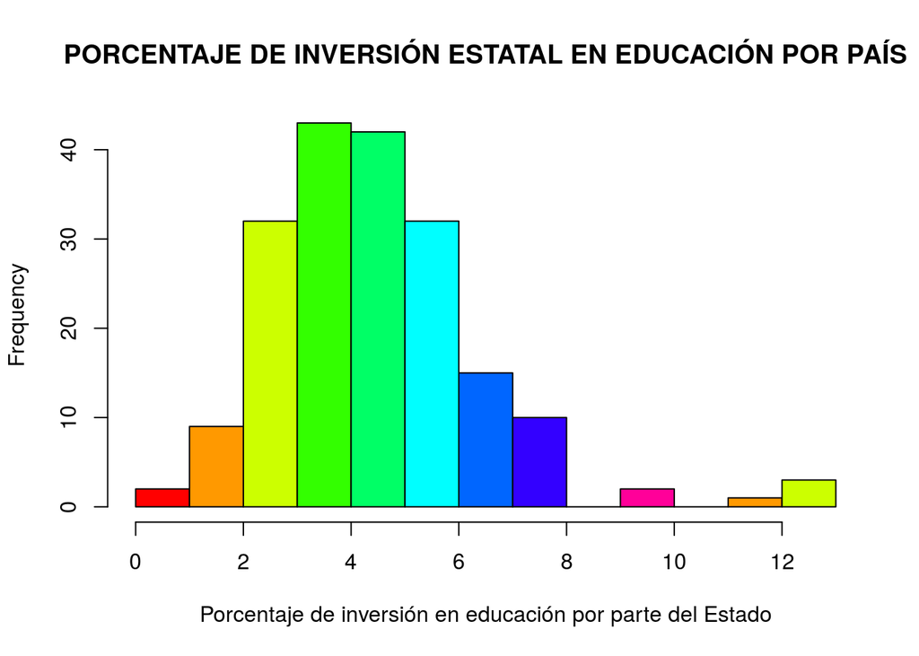

```r
#Ahora, procedemos a realizar nuestro primer gráfico: Histograma de la variable
graficogastoedu <- (datamerge$gastoedu)
hist(graficogastoedu, col= rainbow(10),xlab="Porcentaje de inversión en educación por parte del Estado", main="PORCENTAJE DE INVERSIÓN ESTATAL EN EDUCACIÓN POR PAÍS")
```

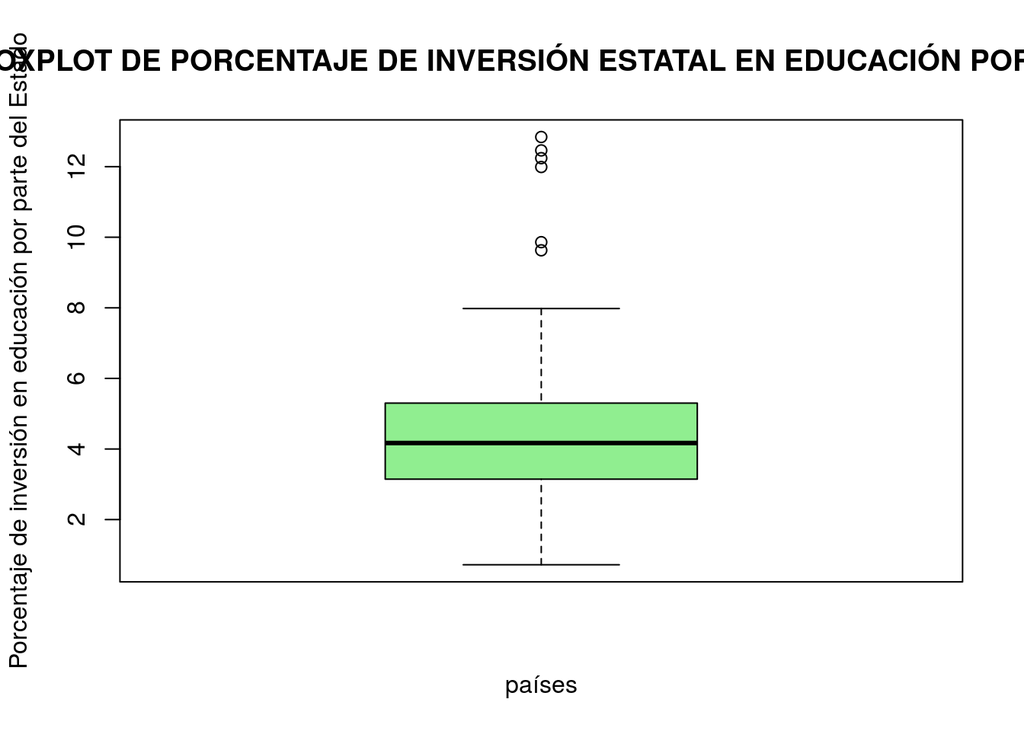

```r
#Haremos nuestro segundo gráfico: Boxplot de la variable. Esto nos servirá para ver cómo se distribuyen los casos.
boxplot(datamerge$gastoedu, main="BOXPLOT DE PORCENTAJE DE INVERSIÓN ESTATAL EN EDUCACIÓN POR PAÍS", col="light green",xlab="países", ylab="Porcentaje de inversión en educación por parte del Estado")
```

6. Variable Ratio de estudiantes por profesor

```r
##Primero identificamos la variable,si nuestra variable se encuentra en numérica, los estadístictos descriptivos a modo de summary.
class(datamerge$profxes)
```

```
## [1] "numeric"
```

```r
summary(datamerge$profxes)
```

```
##    Min. 1st Qu.  Median    Mean 3rd Qu.    Max.    NA's
##   5.841   9.954  13.580  16.401  20.581  72.310      51
```

```r
table(datamerge$profxes)
```

```
##
##  5.84099  6.33229  6.73221  6.95898  7.11247  7.33711  7.57537  7.58836
##        1        1        1        1        1        1        1        1
##  7.67398  7.80821   7.9222    7.946  8.01599  8.01689  8.26843   8.2712
##        1        1        1        1        1        1        1        1
##  8.30834  8.31131  8.54364  8.55985  8.56276  8.57685  8.64286  8.74033
##        1        1        1        1        1        1        1        1
##  8.76378  8.82794  8.98821  9.09854   9.1229  9.18187  9.29704  9.32983
##        1        1        1        1        1        1        1        1
##  9.51599  9.54885  9.55752  9.63133  9.69943  9.82943  9.86318  9.98461
##        1        1        1        1        1        1        1        1
## 10.01652 10.21867 10.23948 10.32977 10.49312 10.64648 10.69423  10.7789
##        1        1        1        1        1        1        1        1
## 10.81456  10.9653  10.9886 10.99168 11.04303 11.06981 11.11967 11.14556
##        1        1        1        1        1        1        1        1
## 11.19927 11.22247 11.29034 11.40208 11.47558 11.52893 11.54847 11.56883
##        1        1        1        1        1        1        1        1
## 11.97424 11.97658 12.07981 12.26127 12.42779 12.48097 12.63651 12.65841
##        1        1        1        1        1        1        1        1
## 12.81206  12.9392 13.07043 13.25879 13.26544 13.57979  13.5809 13.62495
##        1        1        1        1        1        1        1        1
## 13.62875  13.8727 14.20042 14.49262 14.51694  14.5488 14.62452 15.04762
##        1        1        1        1        1        1        1        1
## 15.16281 15.42052 15.43893 15.54522 16.01642 16.61873 16.65963 16.69828
##        1        1        1        1        1        1        1        1
## 16.72317 16.72391 16.85759 17.15997 17.34797 17.43224 17.52875 17.93859
##        1        1        1        1        1        1        1        1
## 18.36688 18.39079  18.4041 18.49627 18.64652 18.88356 19.00886 19.25706
##        1        1        1        1        1        1        1        1
##  19.2926 19.29784 20.29138 20.39658   20.568 20.62112 20.86254 21.46821
##        1        1        1        1        1        1        1        1
## 22.04465 22.48353 23.11995 23.19708 23.88062     24.8 24.82051 25.34293
##        1        1        1        1        1        1        1        1
## 25.41709 25.91073  25.9167 25.92408 25.94603 26.24584 26.59842 26.76619
##        1        1        1        1        1        1        1        1
## 27.13412 27.24679 27.28114 27.47489 27.55579 27.61705 28.24773 28.52287
##        1        1        1        1        1        1        1        1
## 28.82411 29.73171 30.83047 31.63737 33.13554 33.50124  34.2964 35.02165
##        1        1        1        1        1        1        1        1
## 35.09524 36.54379 40.35064 72.31002
##        1        1        1        1
```

```r
#Ahora pedimos algunos estadísticos descriptivos en particular. Si bien también los tenemos en summary, pedimos la mediana, la desviación estándar.
median(datamerge$profxes,na.rm=T)
```

```
## [1] 13.58034
```

```r
mean(datamerge$profxes,na.rm=T)
```

```
## [1] 16.40087
```

```r
Mode(datamerge$profxes,na.rm=T)
```

```
## [1] NA
## attr(,"freq")
## [1] 1
```

```r
sd(datamerge$profxes,na.rm=T)
```

```
## [1] 8.939118
```

```r
#Para visualizar los descriptivos de manera más clara
table1::label(datamerge$profxes) <- "Ratio de estudiantes por maestro"
table1::table1(~profxes, data = datamerge, )
```

|  | Overall (N=207) |
| --- | --- |
| Ratio de estudiantes por maestro |  |
| Mean (SD) | 16.4 (8.94) |
| Median [Min, Max] | 13.6 [5.84, 72.3] |
| Missing | 51 (24.6%) |

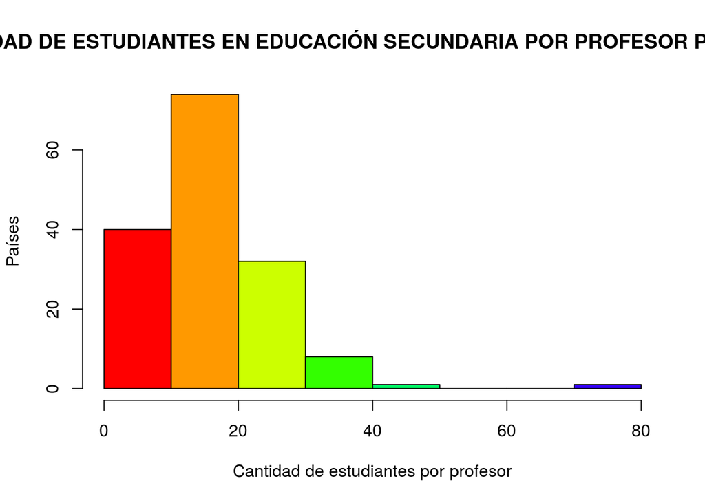

```r
#Ahora, procedemos a realizar nuestro primer gráfico: Histograma de la variable
graficoprofxes <- (datamerge$profxes)
hist(graficoprofxes, col= rainbow(10),
     ylab="Países",
     xlab="Cantidad de estudiantes por profesor",
     main="CANTIDAD DE ESTUDIANTES EN EDUCACIÓN SECUNDARIA POR PROFESOR POR PAÍSES")
```

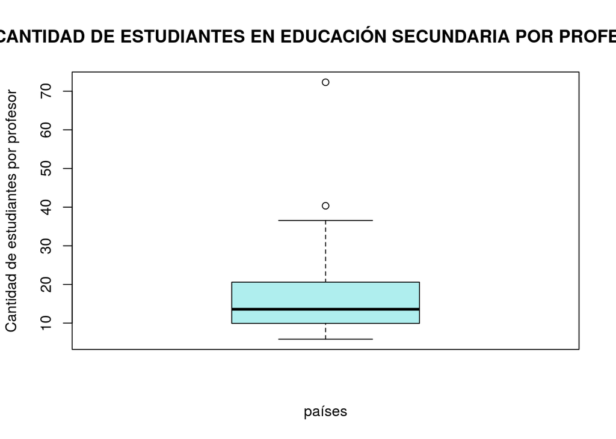

```r
#Haremos nuestro segundo gráfico: Boxplot de la variable. Esto nos servirá para ver cómo se distribuyen los casos.
boxplot(datamerge$profxes, main="BOXPLOT DE CANTIDAD DE ESTUDIANTES EN EDUCACIÓN SECUNDARIA POR PROFESOR POR PAÍSES ", col="paleturquoise", xlab="países", ylab="Cantidad de estudiantes por profesor")
```

7. Variable Porcentaje de jóvenes que consumen alcohol

```r
##Primero identificamos la variable,si nuestra variable se encuentra en numérica, los estadístictos descriptivos a modo de summary.
class(datamerge$totalAC)
```

```
## [1] "numeric"
```

```r
summary(datamerge$totalAC)
```

```
##    Min. 1st Qu.  Median    Mean 3rd Qu.    Max.    NA's
##    0.10   12.90   23.60   28.96   45.20   86.40      18
```

```r
table(datamerge$totalAC)
```

```
##
##  0.1  0.2  0.3  0.5  0.6    1  1.1  1.3  1.4  1.5  1.7    2  2.5  2.6    3  3.3
##    1    1    3    1    1    1    1    2    1    3    1    1    1    1    1    1
##  3.5  3.8  6.6  7.4  7.9  8.2  8.5  9.1  9.8  9.9   10   11 11.5 11.7 11.8   12
##    1    2    1    3    2    1    1    1    1    1    1    1    1    1    2    1
## 12.4 12.5 12.6 12.8 12.9 13.1 13.3 13.8   14   15 15.3 15.4 15.9 16.2 16.3 16.5
##    1    1    1    2    2    1    2    1    1    1    2    1    1    1    1    1
## 16.8 16.9 17.1 17.2 17.5 17.6   18 18.3 18.4 18.7   19 19.2 19.3 19.4 19.5 19.6
##    1    1    1    1    1    1    1    1    1    3    1    1    1    1    1    1
## 20.4 20.5 20.8 20.9 21.1 22.4 22.6 22.7   23 23.4 23.6 23.7 24.4 24.5 24.7   25
##    1    1    2    1    1    1    1    1    1    1    4    1    2    1    1    1
## 25.2 25.5 26.1 26.4 26.8 27.3 27.4 28.2 28.7 29.1 29.8 31.3   32 32.2 32.5 33.2
##    2    1    2    2    1    2    1    1    1    1    1    2    1    1    1    1
## 33.5 34.4 34.9 35.3   36 36.9 37.3 37.5 37.7 38.5 39.4 39.5 40.4 40.6 41.2 41.4
##    1    1    1    2    1    1    1    1    1    1    2    1    1    1    1    1
## 43.9 45.2 45.5 47.3 47.4 49.4 50.5 50.8 51.7 52.3 52.9 53.4 54.1 54.4 54.5 54.6
##    1    1    1    1    1    1    1    1    1    1    1    1    1    1    1    1
## 55.2 55.3 55.6 56.5 56.6 57.1 57.2   58 59.2 59.3 59.6 59.9 60.9 61.9   62 62.3
##    1    1    1    1    1    1    1    2    1    1    1    1    1    1    1    2
## 63.8 63.9 64.2 64.6 65.3 65.4 66.2 68.1 68.8 69.3 70.2 70.6 71.4   72 86.4
##    1    1    1    1    1    1    1    1    1    1    1    1    1    1    1
```

```r
#Ahora pedimos algunos estadísticos descriptivos en particular. Si bien también los tenemos en summary, pedimos la mediana, la desviación estándar.
median(datamerge$totalAC,na.rm=T)
```

```
## [1] 23.6
```

```r
mean(datamerge$totalAC,na.rm=T)
```

```
## [1] 28.9582
```

```r
Mode(datamerge$totalAC,na.rm=T)
```

```
## [1] 23.6
## attr(,"freq")
## [1] 4
```

```r
sd(datamerge$totalAC,na.rm=T)
```

```
## [1] 20.83547
```

```r
#Para visualizar los descriptivos de manera más clara
table1::label(datamerge$totalAC) <- "Porcentaje de jóvenes que consumen alcohol"
table1::table1(~totalAC, data = datamerge, )
```

|  | Overall (N=207) |
| --- | --- |
| Porcentaje de jóvenes que consumen alcohol |  |
| Mean (SD) | 29.0 (20.8) |
| Median [Min, Max] | 23.6 [0.100, 86.4] |
| Missing | 18 (8.7%) |

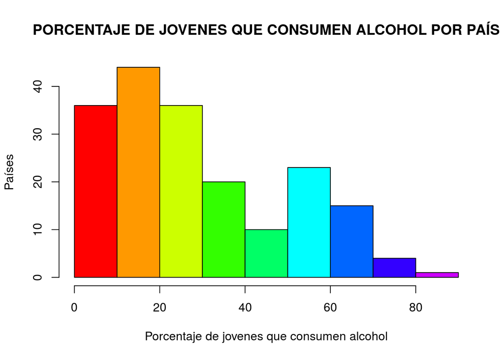

```r
#Ahora, procedemos a realizar nuestro primer gráfico: Histograma de la variable
graficototalAC <- (datamerge$totalAC)
hist(graficototalAC, col= rainbow(10),
     xlab="Porcentaje de jovenes que consumen alcohol",
     ylab="Países",
     main="PORCENTAJE DE JOVENES QUE CONSUMEN ALCOHOL POR PAÍS")
```

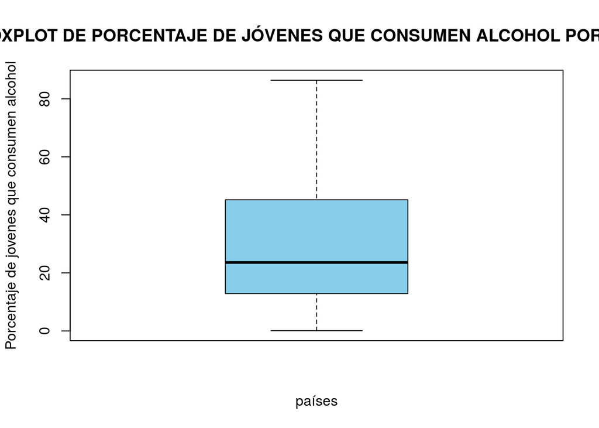

```r
#Haremos nuestro segundo gráfico: Boxplot de la variable. Esto nos servirá para ver cómo se distribuyen los casos.
boxplot(datamerge$totalAC, main="BOXPLOT DE PORCENTAJE DE JÓVENES QUE CONSUMEN ALCOHOL POR PAÍS  ", col="Skyblue",
        xlab="países", ylab="Porcentaje de jovenes que consumen alcohol")
```

8. Variable Porcentaje de natalidad por cada 1000 mujeres de 15 a 19 años por país

```r
##Primero identificamos la variable,si nuestra variable se encuentra en numérica, los estadístictos descriptivos a modo de summary.
class(datamerge$rateper1000AP)
```

```
## [1] "numeric"
```

```r
summary(datamerge$rateper1000AP)
```

```
##    Min. 1st Qu.  Median    Mean 3rd Qu.    Max.    NA's
##    1.00   12.53   38.60   50.94   75.97  229.00      13
```

```r
table(datamerge$rateper1000AP)
```

```
##
##     1   1.4   2.4   2.5   2.7   2.8   2.9   3.4     4   4.1   4.4   4.6   4.9
##     2     1     1     1     1     1     2     1     2     1     2     1     1
##   5.4   5.7   5.9     6   6.3   6.7   7.1   7.2   7.7     8   8.5   8.6   8.7
##     1     1     1     1     1     1     1     1     1     1     1     2     1
##   8.9   9.1   9.2   9.3   9.7   9.8   9.9    10  10.1  10.5  10.7  10.9    11
##     1     1     1     1     1     1     1     1     1     1     1     1     1
##  11.1  11.7  12.1  12.4  12.5  12.6  13.3  13.6  13.8  14.2  15.1  15.2  15.9
##     1     1     1     1     1     1     1     1     1     1     1     1     1
##  16.1  18.8  18.9    19  19.1    20  20.9    21  21.2  21.4  21.5  22.9  23.1
##     1     1     1     1     1     1     1     2     1     1     1     1     1
##    24  25.6  26.4  26.6  26.8    27  27.7    28  28.4    29    30  30.1  32.3
##     1     1     1     1     1     1     1     2     1     1     1     1     1
##  32.6  33.2  33.8  33.9  35.8  35.9    36  37.8    38  38.1  38.2    39  39.2
##     1     1     1     1     1     1     2     1     1     1     1     1     1
##  40.9    41  41.9    44    45    46  46.1    48  48.4    49  49.7    50  50.4
##     1     1     1     2     1     1     1     1     1     1     1     1     1
##    51  51.2  51.7  51.8    52  52.3  52.7    54  54.3  54.4  54.8  56.7  57.4
##     1     1     1     1     1     1     1     1     1     1     1     1     1
##  58.2    61    62  63.9  64.3    67  67.2    68  68.3  70.3  70.5    71  71.1
##     1     1     1     1     1     1     1     1     1     1     1     1     1
##    72  73.7    74  75.1  75.9    76  77.5  77.6    78  78.9  79.5    80  82.1
##     1     1     2     1     1     1     1     1     1     1     1     1     1
##  83.4    84  84.5    86  86.8  87.1  88.2  88.7    91    92    94  94.5    96
##     1     1     1     1     1     1     1     2     1     2     2     1     1
## 101.3   106 106.4   108 111.3   119   120   123 123.3 131.5 132.3   135 137.6
##     1     1     1     1     1     1     1     1     1     1     1     1     1
## 138.1 138.9 150.3   152   154 158.1   163   164   176 179.4   180   229
##     1     1     1     1     1     1     1     1     1     1     1     1
```

```r
#Ahora pedimos algunos estadísticos descriptivos en particular. Si bien también los tenemos en summary, pedimos la mediana, la desviación estándar.
median(datamerge$rateper1000AP,na.rm=T)
```

```
## [1] 38.6
```

```r
mean(datamerge$rateper1000AP,na.rm=T)
```

```
## [1] 50.94278
```

```r
Mode(datamerge$rateper1000AP,na.rm=T)
```

```
##  [1]  1.0  2.9  4.0  4.4  8.6 21.0 28.0 36.0 44.0 74.0 88.7 92.0 94.0
## attr(,"freq")
## [1] 2
```

```r
sd(datamerge$rateper1000AP,na.rm=T)
```

```
## [1] 45.1498
```

```r
#Para visualizar los descriptivos de manera más clara
table1::label(datamerge$rateper1000AP) <- "Porcentaje de natalidad por cada 1000 mujeres de 15 a 19 años"
table1::table1(~rateper1000AP, data = datamerge, )
```

|  | Overall (N=207) |
| --- | --- |
| Porcentaje de natalidad por cada 1000 mujeres de 15 a 19 años |  |
| Mean (SD) | 50.9 (45.1) |
| Median [Min, Max] | 38.6 [1.00, 229] |
| Missing | 13 (6.3%) |

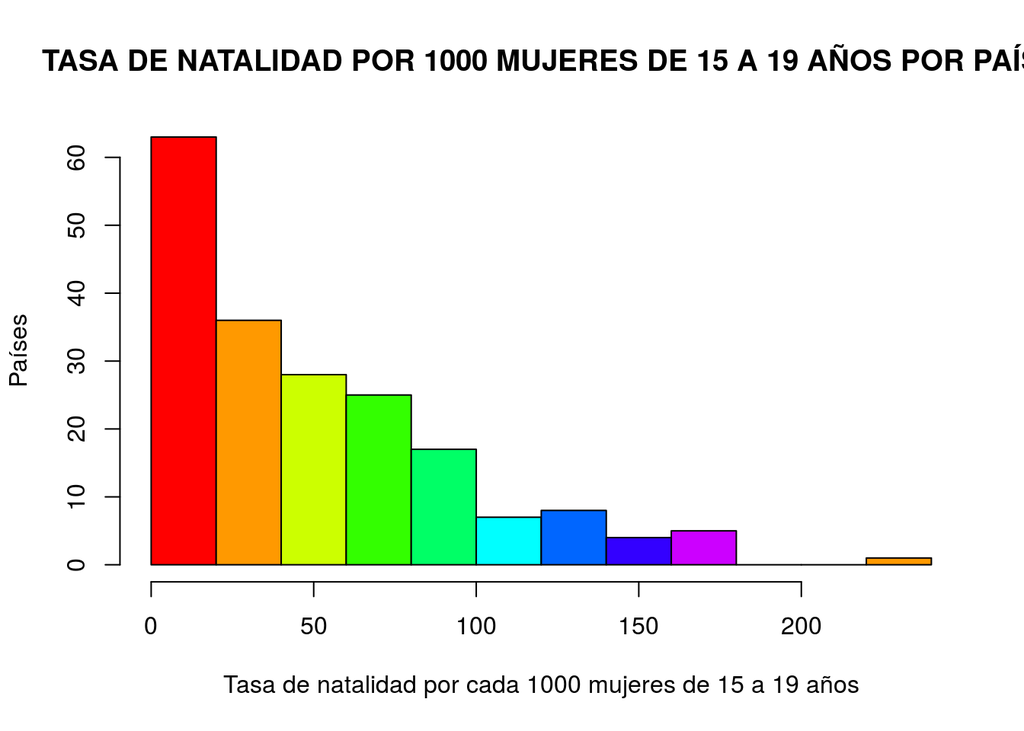

```r
#Ahora, procedemos a realizar nuestro primer gráfico: Histograma de la variable
graficorateper1000AP<- (datamerge$rateper1000AP)
hist(graficorateper1000AP, col= rainbow(10),
     xlab="Tasa de natalidad por cada 1000 mujeres de 15 a 19 años",
     ylab="Países",
     main="TASA DE NATALIDAD POR 1000 MUJERES DE 15 A 19 AÑOS POR PAÍS")
```

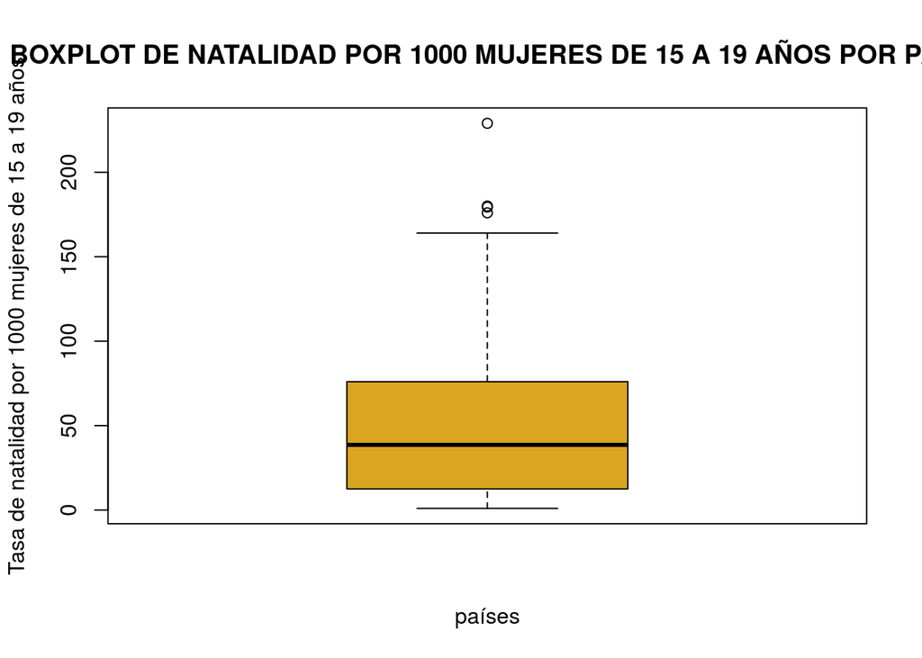

```r
#Haremos nuestro segundo gráfico: Boxplot de la variable. Esto nos servirá para ver cómo se distribuyen los casos.
boxplot(datamerge$rateper1000AP, main="BOXPLOT DE NATALIDAD POR 1000 MUJERES DE 15 A 19 AÑOS POR PAÍS", col="goldenrod",xlab="países", ylab="Tasa de natalidad por 1000 mujeres de 15 a 19 años")
```

*ANÁLISIS BIVARIADO*

V. EXPLICADA = Porcentaje de estudiantes matriculados en educación secundaria por país VARIABLES EXPLICATIVAS:

A)v. EXPLICATIVA1= PBI per cápita por país (nominal)

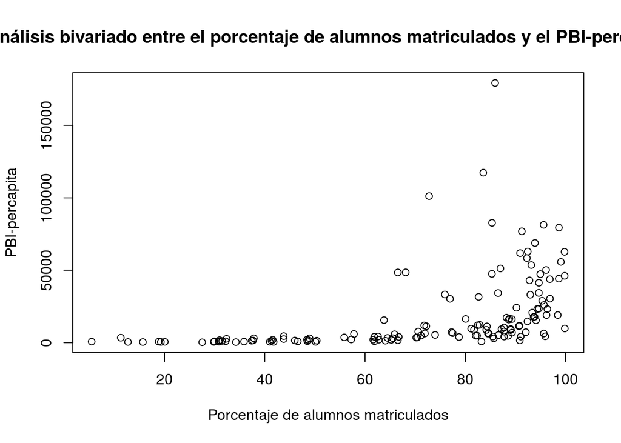

```r
attach(datamerge)
#Primero realizamos el gráfico de dispersión
plot(datamerge$Matricula,datamerge$PBIPC, xlab="Porcentaje de alumnos matriculados",
     ylab="PBI-percapita", main="Análisis bivariado entre el porcentaje de alumnos matriculados y el PBI-percapita")
```

```r
#Procedemos a realizar la prueba de correlación de Pearson
cor.test(datamerge$Matricula, datamerge$PBIPC)
```

```
##
##  Pearson's product-moment correlation
##
## data:  datamerge$Matricula and datamerge$PBIPC
## t = 6.0444, df = 140, p-value = 1.288e-08
## alternative hypothesis: true correlation is not equal to 0
## 95 percent confidence interval:
##  0.3137040 0.5764519
## sample estimates:
##       cor
## 0.4549229
```

B)v. EXPLICATIVA2= Porcentaje de la población bajo la línea nacional de pobreza

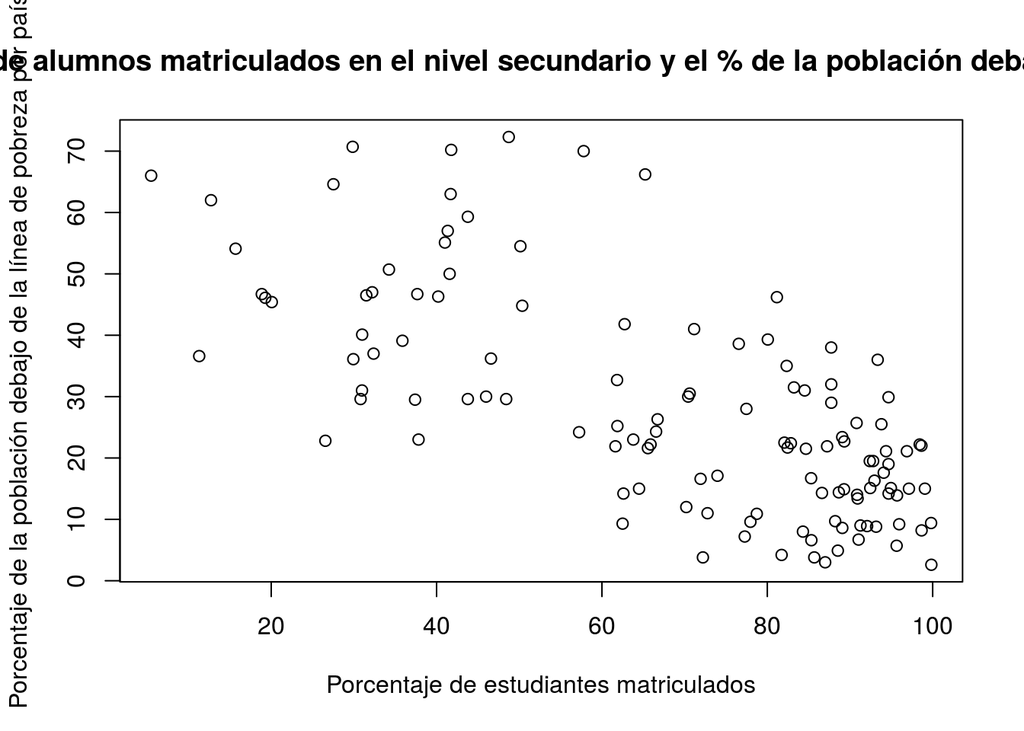

```r
#Primero realizamos el gráfico de dispersión
plot(datamerge$Matricula, datamerge$Pobreza,xlab="Porcentaje de estudiantes matriculados",
     ylab="Porcentaje de la población debajo de la línea de pobreza por país", main="Análisis bivariado entre el % de alumnos matriculados en el nivel secundario y el % de la población debajo de la línea de pobreza por país")
```

```r
#Procedemos a realizar la prueba de correlación de Pearson
cor.test(datamerge$Matricula, datamerge$Pobreza)
```

```
##
##  Pearson's product-moment correlation
##
## data:  datamerge$Matricula and datamerge$Pobreza
## t = -10.674, df = 119, p-value < 2.2e-16
## alternative hypothesis: true correlation is not equal to 0
## 95 percent confidence interval:
##  -0.7804528 -0.5951926
## sample estimates:
##        cor
## -0.6993865
```

C)v. EXPLICATIVA3= Porcentaje de población urbana por país.

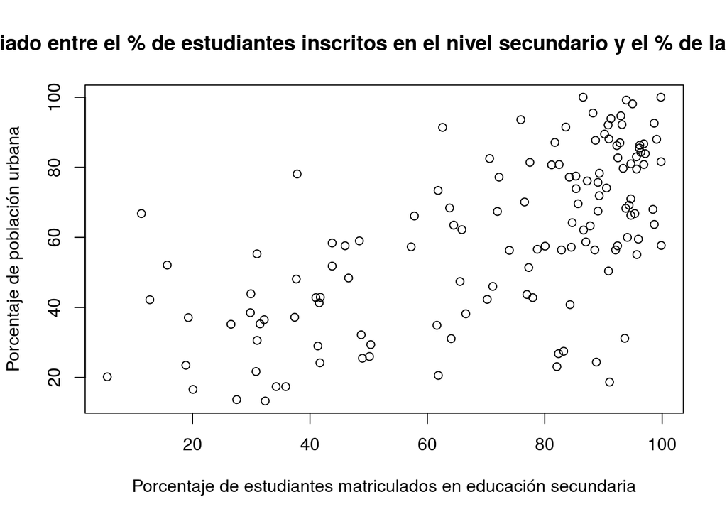

```r
#Primero realizamos el gráfico de dispersión
plot(datamerge$Matricula, datamerge$URBANO,xlab="Porcentaje de estudiantes matriculados en educación secundaria",
     ylab="Porcentaje de población urbana", main="Análisis bivariado entre el % de estudiantes inscritos en el nivel secundario y el % de la población urbana")
```

```r
#Procedemos a realizar la prueba de correlación de Pearson
cor.test(datamerge$Matricula, datamerge$URBANO)
```

```
##
##  Pearson's product-moment correlation
##
## data:  datamerge$Matricula and datamerge$URBANO
## t = 9.4097, df = 130, p-value = 2.355e-16
## alternative hypothesis: true correlation is not equal to 0
## 95 percent confidence interval:
##  0.5224676 0.7281876
## sample estimates:
##      cor
## 0.636515
```

D)v. EXPLICATIVA4= Porcentaje de población femenina por país

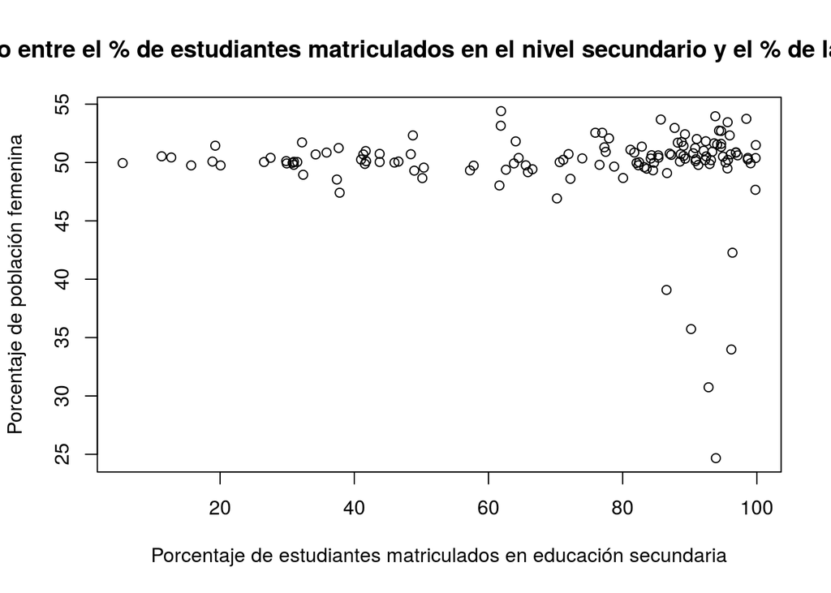

```r
#Primero realizamos el gráfico de dispersión
plot(datamerge$Matricula, datamerge$SEXO,xlab="Porcentaje de estudiantes matriculados en educación secundaria",
     ylab="Porcentaje de población femenina", main="Análisis bivariado entre el % de estudiantes matriculados en el nivel secundario y el % de la población femenina")
```

```r
#Procedemos a realizar la prueba de correlación de Pearson
cor.test(datamerge$Matricula, datamerge$SEXO)
```

```
##
##  Pearson's product-moment correlation
##
## data:  datamerge$Matricula and datamerge$SEXO
## t = -0.94575, df = 130, p-value = 0.346
## alternative hypothesis: true correlation is not equal to 0
## 95 percent confidence interval:
##  -0.25000532  0.08947202
## sample estimates:
##         cor
## -0.08266421
```

E)v. EXPLICATIVA5= Porcentaje del PBI invertido en educación por parte del Estado

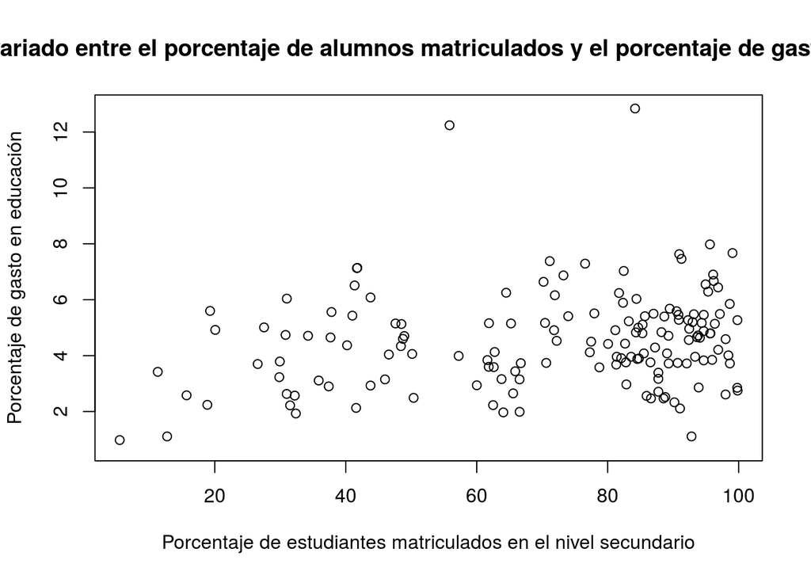

```r
#Primero realizamos el gráfico de dispersión
plot(datamerge$Matricula,datamerge$gastoedu,xlab="Porcentaje de estudiantes matriculados en el nivel secundario",
     ylab="Porcentaje de gasto en educación", main="Análisis bivariado entre el porcentaje de alumnos matriculados y el porcentaje de gasto en educación")
```

```r
#Procedemos a realizar la prueba de correlación de Pearson
cor.test(datamerge$Matricula, datamerge$gastoedu)
```

```
##
##  Pearson's product-moment correlation
##
## data:  datamerge$Matricula and datamerge$gastoedu
## t = 2.6088, df = 153, p-value = 0.009988
## alternative hypothesis: true correlation is not equal to 0
## 95 percent confidence interval:
##  0.05035626 0.35254504
## sample estimates:
##       cor
## 0.2063662
```

6. 22. EXPLICATIVA6= Ratio de estudiantes por profesor

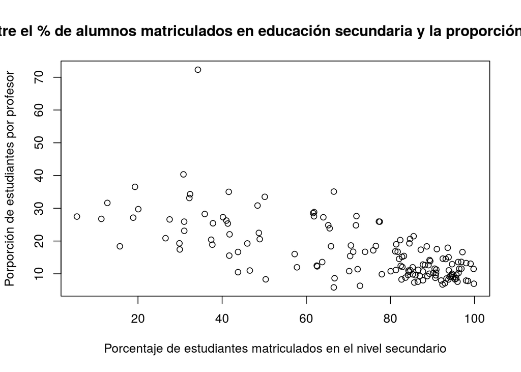

```r
#Primero realizamos el gráfico de dispersión
plot(datamerge$Matricula,datamerge$profxes,xlab="Porcentaje de estudiantes matriculados en el nivel secundario",
     ylab="Porporción de estudiantes por profesor", main="Análisis bivariado entre el % de alumnos matriculados en educación secundaria y la proporción de alumnos por profesor")
```

```r
#Procedemos a realizar la prueba de correlación de Pearson
cor.test(datamerge$Matricula,datamerge$profxes)
```

```
##
##  Pearson's product-moment correlation
##
## data:  datamerge$Matricula and datamerge$profxes
## t = -10.505, df = 141, p-value < 2.2e-16
## alternative hypothesis: true correlation is not equal to 0
## 95 percent confidence interval:
##  -0.7456619 -0.5593027
## sample estimates:
##        cor
## -0.6626172
```

7. 22. EXPLICATIVA7= Porcentaje de jóvenes que consumen alcohol

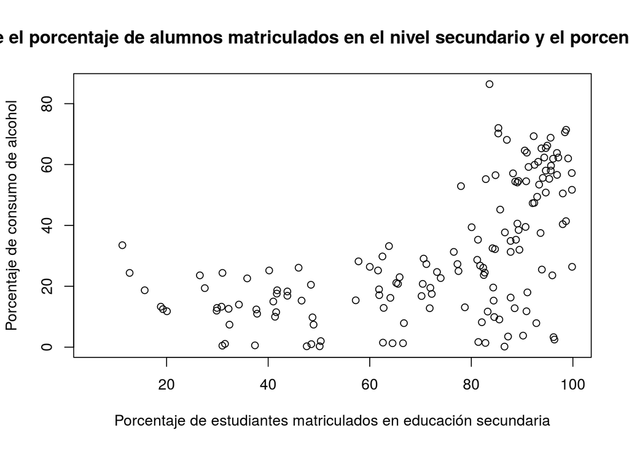

```r
#Primero realizamos el gráfico de dispersión
plot(datamerge$Matricula,datamerge$totalAC,xlab="Porcentaje de estudiantes matriculados en educación secundaria",
     ylab="Porcentaje de consumo de alcohol", main="Análisis bivariado entre el porcentaje de alumnos matriculados en el nivel secundario y el porcentaje de consumo de alcohol")
```

```r
#Procedemos a realizar la prueba de correlación de Pearson
cor.test(datamerge$Matricula,datamerge$totalAC)
```

```
##
##  Pearson's product-moment correlation
##
## data:  datamerge$Matricula and datamerge$totalAC
## t = 8.6096, df = 151, p-value = 8.955e-15
## alternative hypothesis: true correlation is not equal to 0
## 95 percent confidence interval:
##  0.4567218 0.6713638
## sample estimates:
##       cor
## 0.5738146
```

8. 22. EXPLICATIVA8= Porcentaje de natalidad por cada 1000 mujeres de 15 a 19 años por país

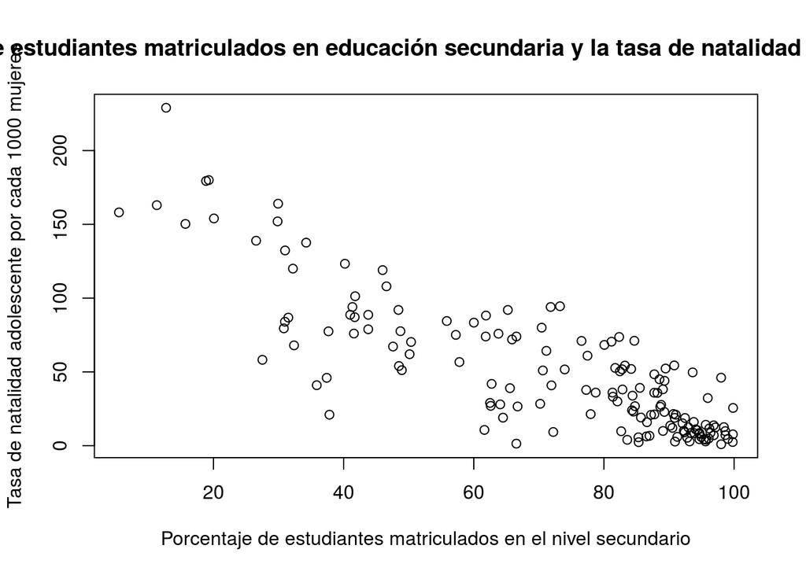

```r
#Primero realizamos el gráfico de dispersión
plot(datamerge$Matricula,datamerge$rateper1000AP,xlab="Porcentaje de estudiantes matriculados en el nivel secundario", ylab="Tasa de natalidad adolescente por cada 1000 mujeres", main="Análisis bivariado entre el % de estudiantes matriculados en educación secundaria y la tasa de natalidad adolescente por cada 1000 mujeres")
```

```r
#Procedemos a realizar la prueba de correlación de Pearson
cor.test(datamerge$Matricula,datamerge$rateper1000AP)
```

```
##
##  Pearson's product-moment correlation
##
## data:  datamerge$Matricula and datamerge$rateper1000AP
## t = -18.885, df = 154, p-value < 2.2e-16
## alternative hypothesis: true correlation is not equal to 0
## 95 percent confidence interval:
##  -0.8776083 -0.7811665
## sample estimates:
##        cor
## -0.8357201
```